Домашнее задание №2 по структурной биоинфорамтике. Сахарова Екатерина 2 курс АДБМ ФКН

TASK 1. Оценила.

TASK 2. Сначала получим отдельно белок и отдельно лиганд. Водородная связь образуется между водородом и электроотрицательным атомом (N, O, F). Сначала найдем все водороды в лиганде и электроотрицательные атомы в белке. Получим все связи между Н и эл.атомами белка. Затем найдем все водороды в белке и эл.атомы в лиганде. Получим все связи между ними. Все имеющееся будет образовывать водородные связи, которыми соединены белок и лиганд.

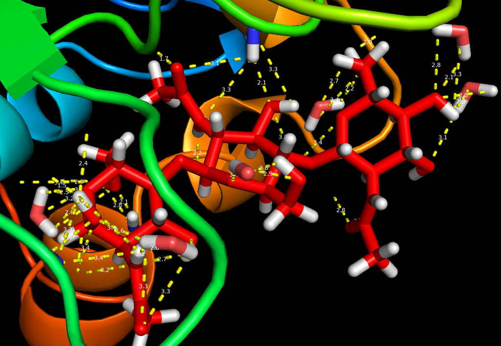

```python
from IPython.display import Image
Image(filename = "2.png", width=500, height=500)
```

TASK 3. Посмотрим на аминокислоты, которые имеют большое количество водородных связей между лигандом и белком. Заменим с помощью Wizard->Mutagenesis одну из них на какую-нибудь аминокислоту (например, PHE), чтобы получились столкновения ("красные пятна").

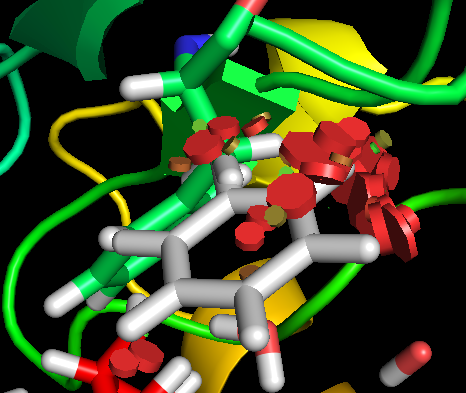

```python
Image(filename = "3.png", width=500, height=500)
```

TASK 4. Создаем ролик: Подключаем необходимые модули и функции.

```python
import pymol
from pymol import cmd
import time
from IPython.display import Image
from threading import Thread

pymol.finish_launching()
```

```python
default_image = '/tmp/pymolimg.png'
def prepareImage(width=300, height=300, filename=default_image, sleep=2):
    cmd.ray(width, height)
    cmd.png(filename)
    time.sleep(sleep)

def focus(x):
    cmd.center(x)
    cmd.zoom(x)
```

Изначально надо подготовить два файла. Исходный белок и мутированный белок. В обоих сразу же в Pymol-е избавимся от лиганда. Сохраним оба белка в формате PDB. Теперь их можно использовать для загрузки в Jupyter.

```python
cmd.do('load ~/Downloads/mutated.pdb')
cmd.do('load ~/Downloads/1lmp_original.pdb')
```

Необходимо получить из Pymol-а номер аминокислотного остатка, который подвергся мутации. В моем случае это был 46 остаток. Отрисуем его.

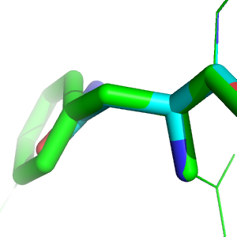

```python
cmd.bg_colour('white')
mutant_resi = 'resi 46'
focus(mutant_resi)
cmd.select(mutant_resi)
cmd.show('sticks', mutant_resi)
cmd.colour('green', 'mutated')
prepareImage()
Image(default_image)
```

Нарисуем изначальное положение двух белков. Красный - без мутации. Зеленый - с мутацией. Разнесем их на некоторое расстрояние друг от друга.

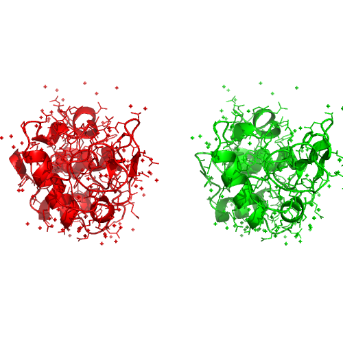

```python
cmd.bg_colour('white')

cmd.set('cartoon_side_chain_helper', 'on')

cmd.show('cartoon', '1lmp_original | mutated')
cmd.colour('red', '1lmp_original')

cmd.translate('[-40, 0, 0]', '1lmp_original')
focus('1lmp_original + mutated')

cmd.zoom('1lmp_original + mutated')

prepareImage(500, 500)
Image(default_image)
```

Создаем ролик с помощью сохранения 300 картинок. Затем из них через консоль можно склеить видео, которое уже и надо загрузить.

```python
near_mutant = 'byres( %s extend 3)' % mutant_resi
cmd.hide('everything', near_mutant)
cmd.show('lines', near_mutant)
cmd.show('sticks', '%s & !1lmp_original' % mutant_resi)

cmd.mset('1 x300')
cmd.frame('1')
cmd.clip('near', '100'); cmd.clip('far', '-100')
cmd.mview('store')
cmd.do('mview store, object=1lmp_original')

cmd.frame('50')
cmd.do('translate [40, 0, 0], object=1lmp_original')
cmd.do('mview store, object=1lmp_original')


cmd.frame('300')
cmd.do('mview store, object=1lmp_original')

cmd.frame('100')
focus('1lmp_original')
cmd.mview('store')

cmd.frame('150')
cmd.do('mview store, object=1lmp_original')
focus(mutant_resi)
cmd.do('util.mrock(150, 300, 300)')
cmd.mview('store')

cmd.frame('300')
focus(mutant_resi)
cmd.clip('near', '100'); cmd.clip('far', '-100')
cmd.mview('store')

cmd.do('mview interpolate, object=1lmp_original')
cmd.mview('reinterpolate')

cmd.set('ray_trace_frames', '1')
cmd.set('ray_trace_mode', '1')
cmd.set('antialias', '1')
cmd.mpng('pic')
```

```python
from IPython.display import HTML
from base64 import b64encode
video = open('movie_1lmp.mp4', 'rb').read()
video_encoded = b64encode(video)
video_tag = '<video controls alt="PyMol Movie" src="data:video/mp4;base64,{0}" type="video/mp4">'.format(video_encoded)
HTML(data=video_tag)
```

[video not shown]

TASK 5. Все делалалось через Pymol. Загрузили белок и метку TAMRA. Затем действуем напрямую по реакции этерификации. Берем метку и видим находим в ней COOH, который будет учавствовать в образовании связи. Удаляем оттуда торчащую гидроксильную группу. Теперь находим аминокислоту в белке, которая имеет висящую снаружи ОН группу. Такая аминокислота - серин. Теперь находим нужный ОН в понравившемся серине и удаляем оттуда Н. Как раз, чтобы в реакции выделялась вода. Оставшиеся "части" белка и метки необходимо склеить.

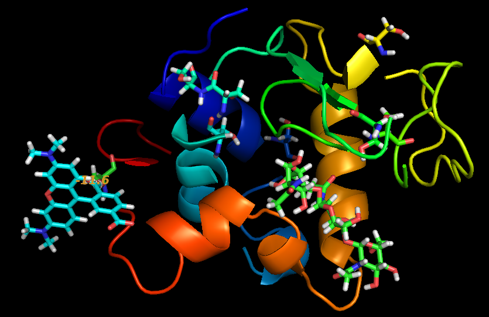

```python
Image(filename = "5.png", width=500, height=500)
```

TASK 6. Построение полиаланиновой спирали. Сначала строим цепь из аланинов. Затем задаем двугранные углы фи и пси.

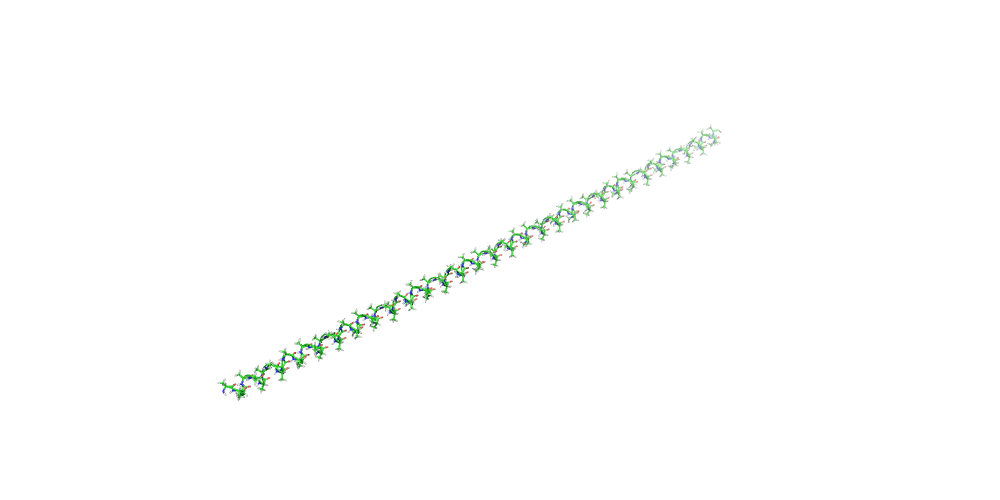

```python
cmd.reinitialize()
cmd.bg_colour('white')

aa  = 'ALA'
ala_phi = '-50'
ala_psi = '-40'
kol = 100

def polyAA(n, aa, phi, psi):
    cmd.fragment(aa)

    for i in range(2, n+1):
        cmd.edit("i. %i & n. C" % i)
        cmd.do('editor.attach_amino_acid("pk1", "%s")' % aa)

    for i in range(2, n+1):
        cmd.set_dihedral("i. %i & n. N" % i, "i. %i & n. CA" % i,
                         "i. %i & n. C" % i, "i. %i & n.  N" % (i+1), phi)
        cmd.set_dihedral("i. %i & n.  C" % i,"i. %i & n. N" % (i+1),
                         "i. %i & n. CA" % (i+1), "i. %i & n. C" % (i+1), psi)

    cmd.edit()
    cmd.show('cartoon', aa)
    focus(aa)

polyAA(kol, aa, ala_phi, ala_psi)

prepareImage(width=1000, height=300,sleep = 0)
Image(default_image)
```